setting up library

```r
library(ggplot2)
library(gridExtra)
library(dplyr)
```

Scatter Plot between price and x in diamonds data set

```r
data(diamonds)
names(diamonds)
```

```
##  [1] "carat"   "cut"     "color"   "clarity" "depth"   "table"   "price"
##  [8] "x"       "y"       "z"
```

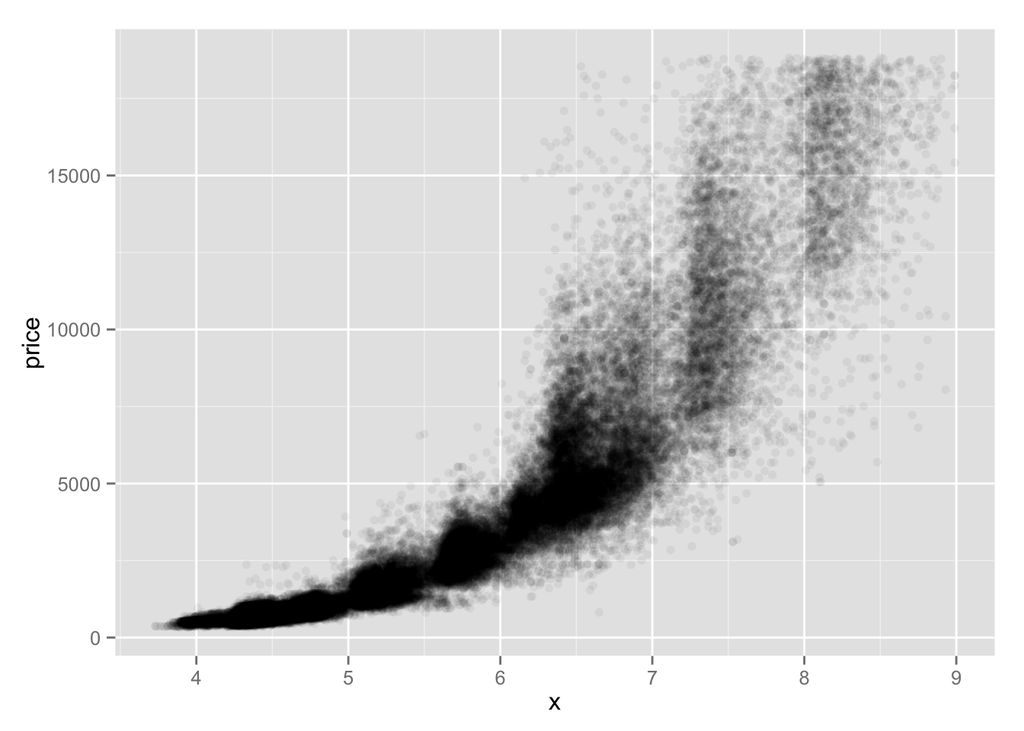

```r
ggplot(aes(x=x,y=price),data=subset(diamonds, x > 3 & x < 9))+
  geom_point(alpha = 1/20)
```

Correlation

```r
cor.test(diamonds$price,diamonds$x)
```

```
##
##  Pearson's product-moment correlation
##
## data:  diamonds$price and diamonds$x
## t = 440.1594, df = 53938, p-value < 2.2e-16
## alternative hypothesis: true correlation is not equal to 0
## 95 percent confidence interval:
##  0.8825835 0.8862594
## sample estimates:
##       cor
## 0.8844352
```

```r
cor.test(diamonds$price,diamonds$y)
```

```
##
##  Pearson's product-moment correlation
##
## data:  diamonds$price and diamonds$y
## t = 401.1415, df = 53938, p-value < 2.2e-16
## alternative hypothesis: true correlation is not equal to 0
## 95 percent confidence interval:
##  0.8632867 0.8675241
## sample estimates:
##       cor
## 0.8654209
```

```r
cor.test(diamonds$price,diamonds$z)
```

```
##
##  Pearson's product-moment correlation
##
## data:  diamonds$price and diamonds$z
## t = 393.6015, df = 53938, p-value < 2.2e-16
## alternative hypothesis: true correlation is not equal to 0
## 95 percent confidence interval:
##  0.8590541 0.8634131
## sample estimates:
##       cor
## 0.8612494
```

scatter plot price vs depth

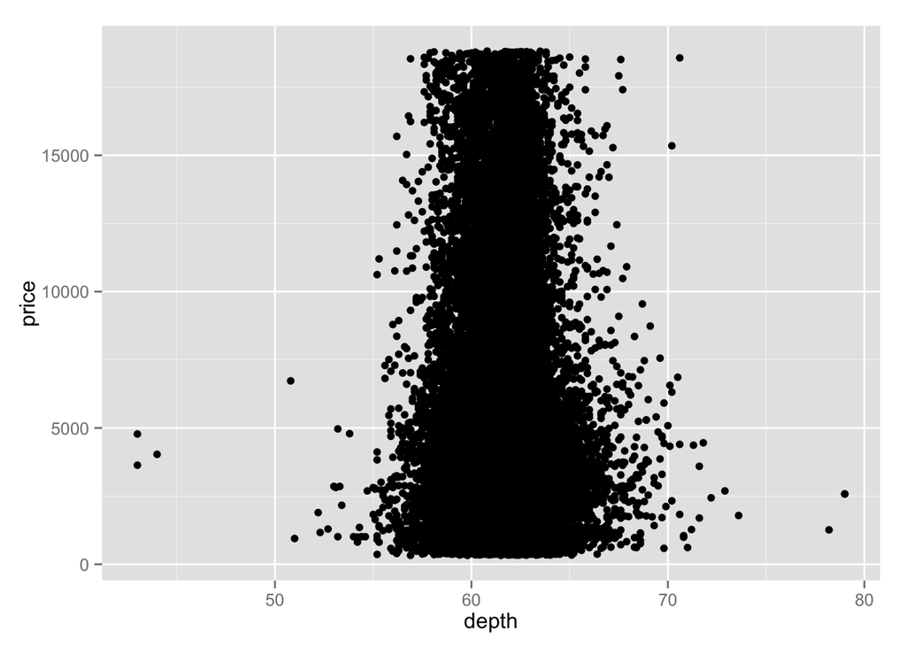

```r
ggplot(aes(x=depth, y = price), data =diamonds)+
  geom_point()
```

Adjustment

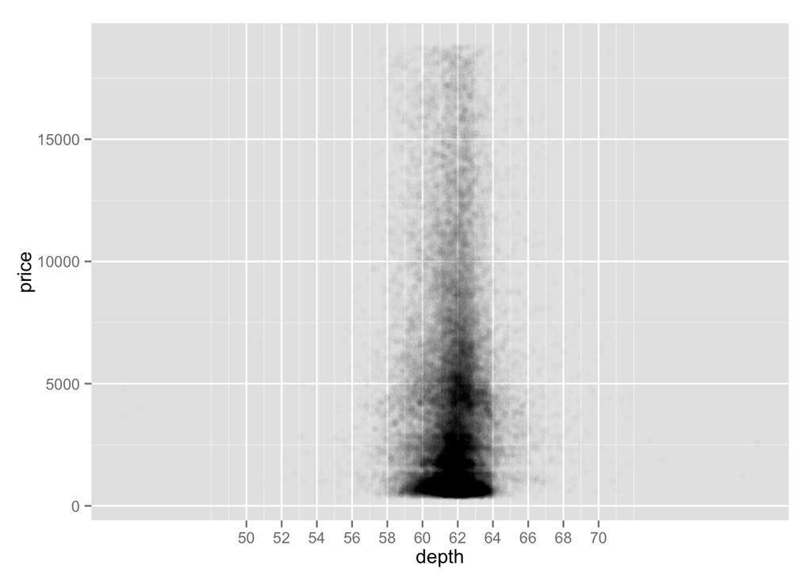

```r
ggplot(aes(x=depth, y = price), data =diamonds)+
  geom_point(alpha = 1/100)+
  scale_x_continuous(breaks = seq(50,70,2))
```

Correlation

```r
cor.test(diamonds$depth, diamonds$price)
```

```
##
##  Pearson's product-moment correlation
##
## data:  diamonds$depth and diamonds$price
## t = -2.473, df = 53938, p-value = 0.0134
## alternative hypothesis: true correlation is not equal to 0
## 95 percent confidence interval:
##  -0.019084756 -0.002208537
## sample estimates:
##        cor
## -0.0106474
```

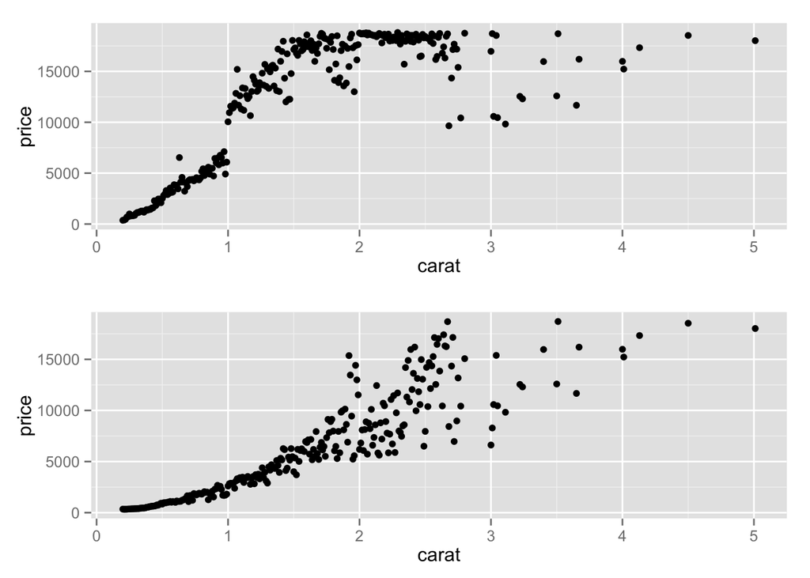

```r
p1 <- ggplot(aes(x=carat,y=price),data=diamonds)+
  geom_point(stat= "summary", fun.y = quantile, probs = 0.99)
p2 <- ggplot(aes(x=carat,y=price),data=diamonds)+
  geom_point(stat= "summary", fun.y = quantile, probs = 0.01)
grid.arrange(p1,p2,ncol=1)
```

price vs volume

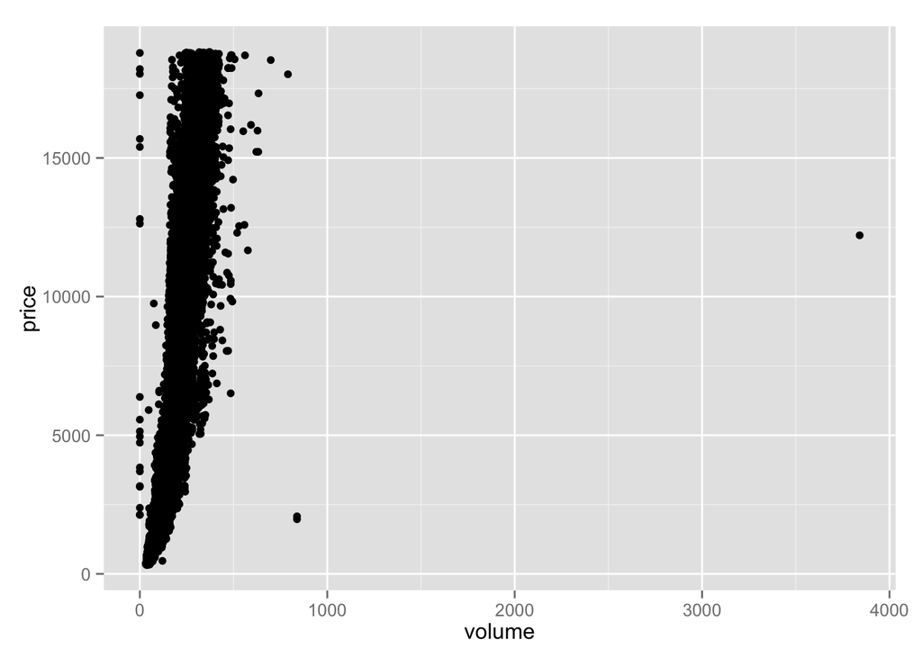

```r
diamonds$volume <- (diamonds$x*diamonds$y)*diamonds$z
ggplot(aes(x=volume,y=price), data=diamonds)+
  geom_point()
```

#Observations seems like linear increase and we can find highly correlation betwen volume and price Did you notice some outliers? Some volumes are 0! There’s an expensive diamond with a volume near 4000, and a cheaper diamond with a volume near 900.

You can find out how many diamonds have 0 volume by using count(diamonds$volume == 0). The count() function comes with the plyr package.

Note: You need to run this command in R to unload the plyr package. detach(“package:plyr”, unload=TRUE) The plyr package will conflict with the dplyr package in later exercises.

Depending on your investigation, it may or may not be important for you to understand how outliers, like these, came to be in your data.

Correlation price vs volume

```r
subdiammondsbyvol <-subset(diamonds,volume>0 & volume <= 800)
cor.test(subdiammondsbyvol$price, subdiammondsbyvol$volume)
```

```
##
##  Pearson's product-moment correlation
##
## data:  subdiammondsbyvol$price and subdiammondsbyvol$volume
## t = 559.1912, df = 53915, p-value < 2.2e-16
## alternative hypothesis: true correlation is not equal to 0
## 95 percent confidence interval:
##  0.9222944 0.9247772
## sample estimates:
##       cor
## 0.9235455
```